# Airbnb Predictive Analytics

## Feature engineering

> Nesta etapa vou criar e testar algumas features para saber se posso considera-las em meu modelo de previsão

##### Novas features:

- Distancia dos principais pontos turisticos para os bairros onde estão localizados os imoveis;
- interação com a distancia;
- Amenities, avaliar se as comodidades podem influenciar no preco;
- Classificar comodidades como populares;
- Criar uma Razão de acomodantes por quarto/banheiro/cama;
- Criar uma Razão de banheiro por quarto;
- Criar uma Razão de camas por quarto;
- Criar indicadores de conforto com as variaveis Razao.

```python
# Coordenadas dos pontos turísticos no Rio de Janeiro
pontos_turisticos = {
    "Cristo Redentor": (-22.9519, -43.2105),
    "Pão de Açúcar": (-22.9486, -43.1574),
    "Maracanã": (-22.9121, -43.2302),
    "Copacabana": (-22.9711, -43.1822),
    "Museu do Amanhã": (-22.8948, -43.1808),
    "Escadaria Selarón": (-22.9137, -43.1815)
}

# Dataframe com coordenadas dos bairros
distancias = []

for index, row in bairro_coords.iterrows():
    bairro = row['neighbourhood_cleansed']
    coord_bairro = (row['latitude'], row['longitude'])

    # Calcula a distância de cada bairro para cada ponto turístico
    dist_bairro = {f"dist_{pt}": haversine(coord_bairro, coord) for pt, coord in pontos_turisticos.items()}

    # Adiciona o bairro e suas distâncias ao resultado
    dist_bairro["bairro"] = bairro
    distancias.append(dist_bairro)

# Criando df com as distâncias
df_distancias = pd.DataFrame(distancias)


df_distancias.head()
```

|  | dist_Cristo Redentor | dist_Pão de Açúcar | dist_Maracanã | dist_Copacabana | dist_Museu do Amanhã | dist_Escadaria Selarón | bairro |
| --- | --- | --- | --- | --- | --- | --- | --- |
| 0 | 11.376068 | 15.830301 | 7.374088 | 14.973124 | 11.956575 | 12.198556 | Abolição |
| 1 | 5.790482 | 11.199704 | 6.817586 | 8.561955 | 11.600743 | 10.264460 | Alto da Boa Vista |
| 2 | 24.239856 | 28.578569 | 20.093538 | 27.838688 | 23.853270 | 24.596274 | Anchieta |
| 3 | 4.866449 | 9.622538 | 2.272844 | 8.464169 | 7.614747 | 6.888978 | Andaraí |
| 4 | 13.008033 | 18.448936 | 11.850165 | 16.047172 | 17.262726 | 16.534719 | Anil |

```python
# Mesclar os dados de distância com o dataframe que contém o preço médio
bairro_dist_price = pd.merge(bairro_coords, df_distancias, left_on="neighbourhood_cleansed", right_on="bairro", how="left")

bairro_dist_price["price"] = bairro_dist_price["price"].round(2)

# print novo dabs
bairro_dist_price.head()
```

|  | neighbourhood_cleansed | id | latitude | longitude | price | dist_Cristo Redentor | dist_Pão de Açúcar | dist_Maracanã | dist_Copacabana | dist_Museu do Amanhã | dist_Escadaria Selarón | bairro |
| --- | --- | --- | --- | --- | --- | --- | --- | --- | --- | --- | --- | --- |
| 0 | Abolição | 124 | -22.888051 | -43.297290 | 519.66 | 11.376068 | 15.830301 | 7.374088 | 14.973124 | 11.956575 | 12.198556 | Abolição |
| 1 | Alto da Boa Vista | 711 | -22.964094 | -43.265482 | 527.29 | 5.790482 | 11.199704 | 6.817586 | 8.561955 | 11.600743 | 10.264460 | Alto da Boa Vista |
| 2 | Anchieta | 95 | -22.820226 | -43.399078 | 480.51 | 24.239856 | 28.578569 | 20.093538 | 27.838688 | 23.853270 | 24.596274 | Anchieta |
| 3 | Andaraí | 1117 | -22.924667 | -43.247702 | 490.25 | 4.866449 | 9.622538 | 2.272844 | 8.464169 | 7.614747 | 6.888978 | Andaraí |
| 4 | Anil | 1103 | -22.951905 | -43.337541 | 406.01 | 13.008033 | 18.448936 | 11.850165 | 16.047172 | 17.262726 | 16.534719 | Anil |

```python
# Calcular a correlação entre o preço e as distâncias
correlacoes = bairro_dist_price[["price", "dist_Cristo Redentor", "dist_Pão de Açúcar",
                                 "dist_Maracanã", "dist_Copacabana", "dist_Museu do Amanhã","dist_Escadaria Selarón"]].corr()

# Exibir as correlações de 'price' com cada ponto turístico
correlacoes["price"]
```

```
price                     1.000000
dist_Cristo Redentor     -0.053777
dist_Pão de Açúcar        0.003344
dist_Maracanã            -0.026823
dist_Copacabana          -0.043552
dist_Museu do Amanhã      0.056705
dist_Escadaria Selarón    0.030044
Name: price, dtype: float64
```

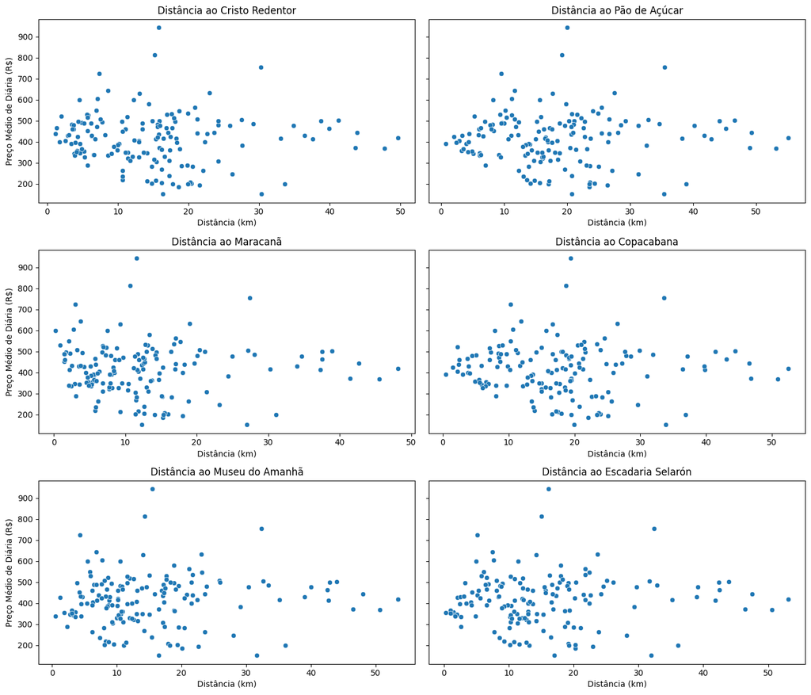

```python
# Adicionar o novo ponto turístico
pontos_turisticos = {
    "dist_Cristo Redentor": (-22.9519, -43.2105),
    "dist_Pão de Açúcar": (-22.9486, -43.1574),
    "dist_Maracanã": (-22.9121, -43.2302),
    "dist_Copacabana": (-22.9711, -43.1822),
    "dist_Museu do Amanhã": (-22.8948, -43.1808),
    "dist_Escadaria Selarón": (-22.9137, -43.1815)
}

# Configurar a figura com subplots (3 linhas e 2 colunas)
fig, axes = plt.subplots(3, 2, figsize=(14, 12), sharey=True)  # Compartilhar eixo y para consistência

# Lista dos pontos turísticos para iteração
pontos_turisticos_keys = list(pontos_turisticos.keys())

# Gerar o gráfico de dispersão para cada ponto turístico
for i, ponto in enumerate(pontos_turisticos_keys):
    row, col = divmod(i, 2)  # Calcula a linha e coluna para o subplot atual
    sns.scatterplot(data=bairro_dist_price, x=ponto, y="price", ax=axes[row, col])
    axes[row, col].set_title(f"Distância ao {ponto.split('_')[1]}")  # Exibe o nome do ponto turístico no título
    axes[row, col].set_xlabel("Distância (km)")
    if col == 0:
        axes[row, col].set_ylabel("Preço Médio de Diária (R$)")
    else:
        axes[row, col].set_ylabel("")

# Ajuste de layout para espaçamento adequado
plt.tight_layout()
plt.show()
```

#### Interpretação Geral

A distância até esses pontos turísticos específicos não é um fator determinante para o preço das diárias. Temos a confirmação desta analise com os gráficos de dispersão, nele podemos ver que a distância dos pontos turísticos não influenciam no preço médio.

Outros fatores (como características dos imóveis, qualidade das acomodações, ou a popularidade geral do bairro) provavelmente têm uma influência muito maior no preço. Essa análise sugere que, para este dataset, a localização em relação aos pontos turísticos não é um fator relevante para a precificação das diárias de aluguel.

```python
# Contar o número de amenidades para cada imóvel
df_airbnb['num_amenidades'] = df_airbnb['amenities'].apply(lambda x: len(x.split(',')) if pd.notnull(x) else 0)
```

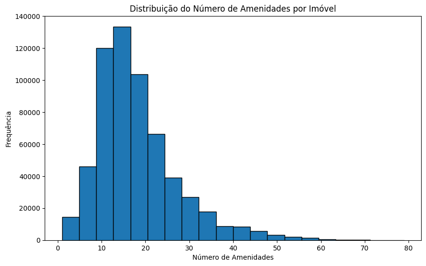

```python
plt.figure(figsize=(10, 6))
df_airbnb['num_amenidades'].plot(kind='hist', bins=20, edgecolor='black')
plt.title('Distribuição do Número de Amenidades por Imóvel')
plt.xlabel('Número de Amenidades')
plt.ylabel('Frequência')
plt.show()
```

```python
# Remover chaves `{}` e aspas `"` e transformar em listas
df_airbnb['amenities'] = df_airbnb['amenities'].str.replace(r'[\{\}"]', '', regex=True)
df_airbnb['amenities'] = df_airbnb['amenities'].str.split(',')
```

```python
# Converter cada amenidade para minúscula e remover espaços
df_airbnb['amenities'] = df_airbnb['amenities'].apply(lambda x: [item.strip().lower() for item in x] if isinstance(x, list) else [])
```

```python
# Visualizar os primeiros exemplos da coluna 'amenities' após a limpeza
df_airbnb['amenities'].head(10)
```

```
1     [tv, cable tv, internet, wifi, air conditionin...
2     [tv, cable tv, wifi, air conditioning, first a...
3     [tv, cable tv, internet, wifi, air conditionin...
4     [tv, cable tv, internet, wifi, air conditionin...
5     [tv, cable tv, internet, wifi, air conditionin...
6     [tv, cable tv, wifi, air conditioning, kitchen...
11    [cable tv, wifi, air conditioning, kitchen, fr...
12    [tv, cable tv, internet, wifi, air conditionin...
13    [tv, cable tv, internet, wifi, air conditionin...
14    [tv, cable tv, internet, wifi, air conditionin...
Name: amenities, dtype: object
```

```python
# Lista de amenidades populares que queremos verificar
amenidades_populares = ['wifi', 'cable tv', 'air conditioning', 'kitchen', "free parking on premises"]

# Criar colunas binárias para cada amenidade popular
for amenidade in amenidades_populares:
    df_airbnb[f'has_{amenidade.replace(" ", "_")}'] = df_airbnb['amenities'].apply(lambda x: 1 if amenidade in x else 0)
```

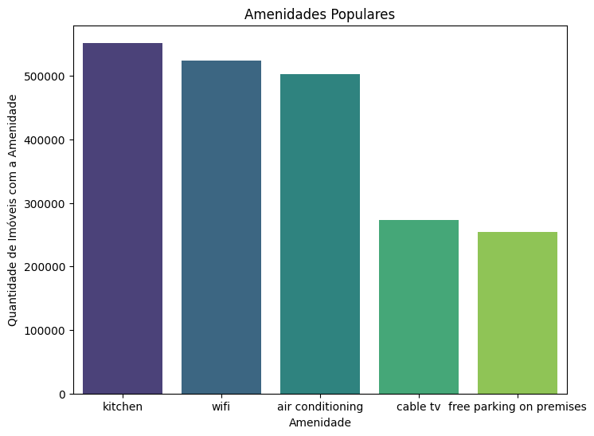

```python
# Contar a frequência de cada amenidade popular
amenidade_counts = {
    amenidade: df_airbnb[f'has_{amenidade.replace(" ", "_")}'].sum()
    for amenidade in amenidades_populares
}

# Converter para um DataFrame
amenidade_counts_df = pd.DataFrame.from_dict(amenidade_counts, orient='index', columns=['Contagem'])
amenidade_counts_df = amenidade_counts_df.sort_values(by='Contagem', ascending=False)


plt.figure(figsize=(8, 6))
sns.barplot(x=amenidade_counts_df.index, y='Contagem', data=amenidade_counts_df, palette='viridis', hue=amenidade_counts_df.index)
plt.legend([],[], frameon=False)
plt.title("Amenidades Populares")
plt.xlabel("Amenidade")
plt.ylabel("Quantidade de Imóveis com a Amenidade")
plt.show()
```

```python
# Calcular a correlação entre o preço e as amenidades
amenity_columns = [f'has_{amenidade.replace(" ", "_")}' for amenidade in amenidades_populares]
correlacoes = df_airbnb[['price'] + amenity_columns].corr()

# Exibir a correlação entre preço e amenidades
correlacoes['price'].sort_values(ascending=False)
```

```
price                           1.000000
has_free_parking_on_premises    0.227065
has_air_conditioning            0.062194
has_kitchen                     0.047523
has_cable_tv                    0.045886
has_wifi                       -0.024649
Name: price, dtype: float64
```

```python
# Comparar preços médios com e sem cada amenidade
precos_amenidades = {}

for amenidade in amenidade_counts_df.index:
    coluna = f'has_{amenidade.replace(" ", "_")}'
    media_com_amenidade = df_airbnb[df_airbnb[coluna] == 1]['price'].mean()
    media_sem_amenidade = df_airbnb[df_airbnb[coluna] == 0]['price'].mean()
    precos_amenidades[amenidade] = {
        'Média com amenidade': media_com_amenidade,
        'Média sem amenidade': media_sem_amenidade
    }

# Converter para DataFrame e exibir
precos_amenidades_df = pd.DataFrame(precos_amenidades).T
precos_amenidades_df
```

|  | Média com amenidade | Média sem amenidade |
| --- | --- | --- |
| kitchen | 447.816883 | 397.890450 |
| wifi | 441.398513 | 462.299414 |
| air conditioning | 451.540984 | 403.976556 |
| cable tv | 457.974830 | 432.230700 |
| free parking on premises | 517.833076 | 389.454547 |

### Nota:

1. **has_free_parking_on_premises** = 0.227065: Essa é a correlação mais alta encontrada (embora ainda moderada), sugerindo que imóveis com estacionamento gratuito no local tendem a ter preços mais altos. Uma correlação de 0.227 indica que a presença dessa amenidade pode influenciar o preço, mas não é um fator decisivo sozinho.
2. **has_cable_tv** = 0.045886: Similar à cozinha, a presença de TV a cabo tem uma correlação muito fraca e positiva com o preço. A influência da TV a cabo no preço é mínima.
3. **has_wifi = -0.024649**: A correlação entre a presença de Wi-Fi e o preço é ligeiramente negativa. Isso sugere que imóveis com Wi-Fi tendem a ter preços ligeiramente mais baixos. No entanto, essa correlação é tão próxima de zero que a influência do Wi-Fi no preço também é mínima.

#### Conclusão Geral

Essas correlações indicam que:

Estacionamento gratuito no local parece ser a amenidade com a maior associação positiva ao preço, embora ainda seja uma correlação moderada (0.227). Isso pode indicar que imóveis com estacionamento gratuito tendem a cobrar um pouco mais, talvez por atender a uma demanda de conforto adicional. Ar-condicionado, cozinha e TV a cabo têm uma correlação muito fraca e positiva, sugerindo uma influência mínima no preço. Wi-Fi tem uma correlação ligeiramente negativa, o que pode indicar que o Wi-Fi é uma comodidade comum e, portanto, não justifica um aumento de preço.

#### Interpretação para o Projeto

Esses resultados indicam que as amenidades podem não ser o principal fator que influencia o preço, exceto talvez o estacionamento gratuito, que pode agregar algum valor. Outros fatores, tamanho do imóvel e a densidade de acomodações, provavelmente terão uma influência maior.

Essa análise sugere que amenidades básicas são esperadas pelos hóspedes, e é mais provável que o preço seja determinado por atributos mais diferenciadores.

```python
#Criar uma Razão de Acomodantes por Quarto
df_airbnb['acomodantes_por_quarto'] = df_airbnb['accommodates'] / df_airbnb['bedrooms']
```

**Criar uma Razão de Acomodantes por Quarto**

- A razão entre o número de acomodantes e o número de quartos pode indicar a densidade de hóspedes por quarto, que é relevante para o conforto.

**Interpretação:**

- Valores mais baixos podem indicar mais conforto (mais espaço por quarto), enquanto valores mais altos podem indicar uma maior densidade de hóspedes por quarto.

```python
#Criar uma Razão de Banheiro por Quarto
df_airbnb['banheiros_por_quarto'] = df_airbnb['bathrooms'] / df_airbnb['bedrooms']
```

**Criar uma Razão de Banheiro por Quarto:**

- A quantidade de banheiros por quarto pode ser um indicador de conforto e conveniência para os hóspedes.

**Interpretação:**

- Imóveis com mais banheiros por quarto tendem a ser mais confortáveis e podem justificar um preço mais alto.

```python
#Criar uma Razão de Camas por Quarto
df_airbnb['camas_por_quarto'] = df_airbnb['beds'] / df_airbnb['bedrooms']
```

**Criar uma Razão de Camas por Quarto:**

- Esse recurso ajuda a entender a densidade de camas por quarto, que pode influenciar o número máximo de hóspedes.

**Interpretação:**

- Valores mais altos indicam mais camas por quarto, o que pode sugerir uma capacidade maior de acomodação em menos espaço.

```python
#Criar uma Razão de Acomodantes por Cama
df_airbnb['acomodantes_por_cama'] = df_airbnb['accommodates'] / df_airbnb['beds']
```

**Criar uma Razão de Acomodantes por Cama:**

- Este indicador mostra quantas pessoas em média são acomodadas por cama, o que também pode afetar o conforto.

**Interpretação:**

- Valores mais baixos indicam mais conforto (menos pessoas por cama), enquanto valores mais altos podem indicar uma densidade maior de pessoas por cama.

```python
# Criar uma Razão de Banheiro por Acomodante
df_airbnb['banheiros_por_acomodante'] = df_airbnb['bathrooms'] / df_airbnb['accommodates']
```

**Criar uma Razão de Banheiro por Acomodante:**

- Esse indicador mostra quantas pessoas compartilham um banheiro, o que pode ser importante para o conforto e privacidade.

**Interpretação:**

- Valores mais altos indicam mais banheiros por pessoa, o que pode ser um ponto positivo em termos de conforto.

```python
#Criar Indicadores de Conforto (Pontuação)
df_airbnb['pontuacao_conforto'] = (df_airbnb['acomodantes_por_quarto'] + df_airbnb['banheiros_por_acomodante']) / 2
```

```python
#Classificar Imóveis por Tipo de Acomodação (Espaço)

def classificar_acomodacao(row):
    if row['acomodantes_por_quarto'] > 2 and row['acomodantes_por_cama'] > 1:
        return 'Econômico'
    elif row['acomodantes_por_quarto'] <= 2 and row['acomodantes_por_cama'] <= 1:
        return 'Luxo'
    else:
        return 'Confortável'

df_airbnb['tipo_acomodacao'] = df_airbnb.apply(classificar_acomodacao, axis=1)
```

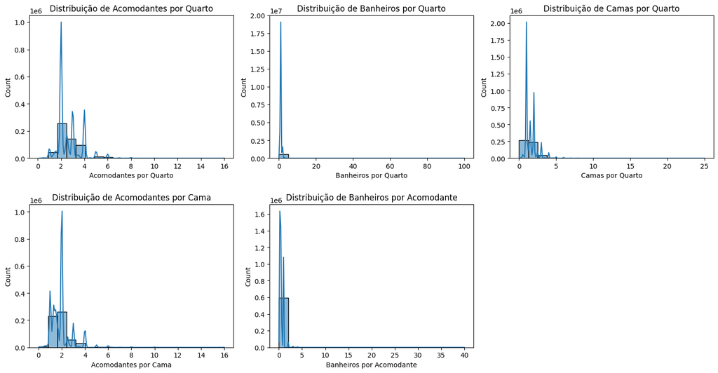

```python
#Distribuição das Razões (Acomodantes por Quarto, Banheiros por Quarto, etc.)
# Configurar o tamanho da figura
plt.figure(figsize=(15, 8))

# Acomodantes por Quarto
plt.subplot(2, 3, 1)
sns.histplot(df_airbnb['acomodantes_por_quarto'], bins=20, kde=True)
plt.title("Distribuição de Acomodantes por Quarto")
plt.xlabel("Acomodantes por Quarto")

# Banheiros por Quarto
plt.subplot(2, 3, 2)
sns.histplot(df_airbnb['banheiros_por_quarto'], bins=20, kde=True)
plt.title("Distribuição de Banheiros por Quarto")
plt.xlabel("Banheiros por Quarto")

# Camas por Quarto
plt.subplot(2, 3, 3)
sns.histplot(df_airbnb['camas_por_quarto'], bins=20, kde=True)
plt.title("Distribuição de Camas por Quarto")
plt.xlabel("Camas por Quarto")

# Acomodantes por Cama
plt.subplot(2, 3, 4)
sns.histplot(df_airbnb['acomodantes_por_cama'], bins=20, kde=True)
plt.title("Distribuição de Acomodantes por Cama")
plt.xlabel("Acomodantes por Cama")

# Banheiros por Acomodante
plt.subplot(2, 3, 5)
sns.histplot(df_airbnb['banheiros_por_acomodante'], bins=20, kde=True)
plt.title("Distribuição de Banheiros por Acomodante")
plt.xlabel("Banheiros por Acomodante")

plt.tight_layout()
plt.show()
```

#### Nota:

#### Interpretação Geral

Essas distribuições mostram as configurações típicas e atípicas dos imóveis em relação ao espaço e conforto:

- **Configurações Padrão:** A maioria dos imóveis segue configurações normais, com um número razoável de acomodantes, camas e banheiros. Isso indica que a maior parte dos imóveis é adequada para pequenas famílias ou grupos moderados.
- **Configurações Atípicas:** Os valores extremos em algumas dessas distribuições (como muitos banheiros por quarto ou muitos acomodantes por cama) sugerem que existem imóveis com configurações especiais, como hostels, dormitórios ou acomodações de luxo com muitos banheiros, sabendo que neste df temos cerca de 0.6% de acomdações compartilhadas conseguimos entender os outliers apresentados.

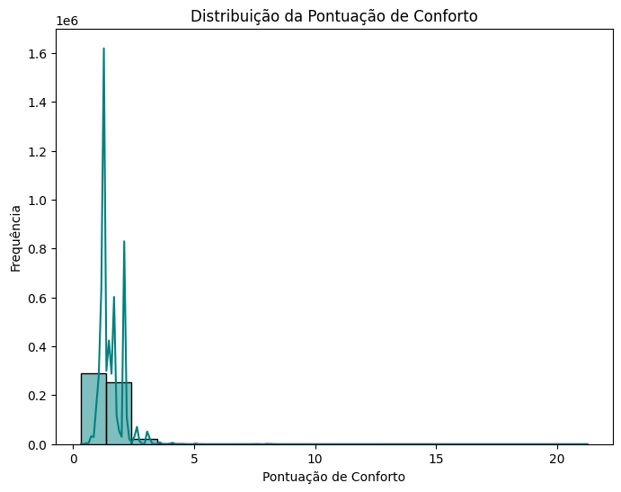

```python
# Distribuição da Pontuação de Conforto
plt.figure(figsize=(8, 6))
sns.histplot(df_airbnb['pontuacao_conforto'], bins=20, kde=True, color='teal')
plt.title("Distribuição da Pontuação de Conforto")
plt.xlabel("Pontuação de Conforto")
plt.ylabel("Frequência")
plt.show()
```

1. **Distribuição da Pontuação de Conforto:**
   - A maioria dos imóveis tem uma pontuação de conforto baixa, mas vemos algumas pontuações mais altas, indicando que certos imóveis oferecem configurações significativamente mais confortáveis. Esses imóveis provavelmente são mais caros.

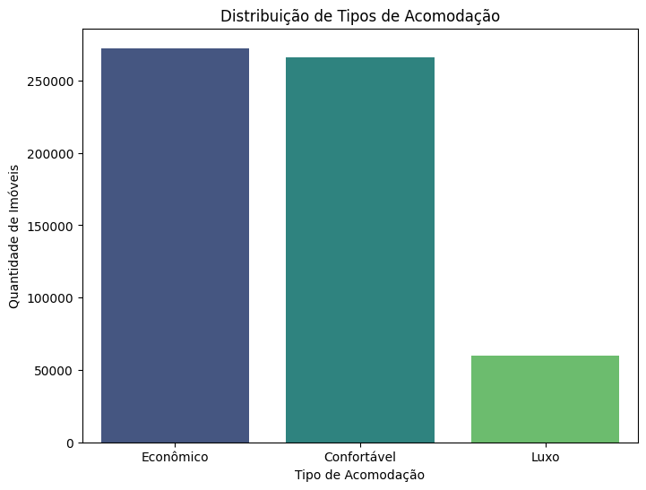

```python
#Contagem de Classificação de Tipo de Acomodação
plt.figure(figsize=(8, 6))
sns.countplot(data=df_airbnb, x='tipo_acomodacao', hue='tipo_acomodacao', palette='viridis')
plt.title("Distribuição de Tipos de Acomodação")
plt.xlabel("Tipo de Acomodação")
plt.ylabel("Quantidade de Imóveis")
plt.show()
```

2. **Distribuição de Tipos de Acomodação:**
   - A maioria dos imóveis está nas categorias "Econômico" e "Confortável", enquanto a categoria "Luxo" representa uma menor proporção.Essa classificação indica que a maioria dos imóveis atende a públicos com preferências de acomodação acessível ou de conforto moderado.

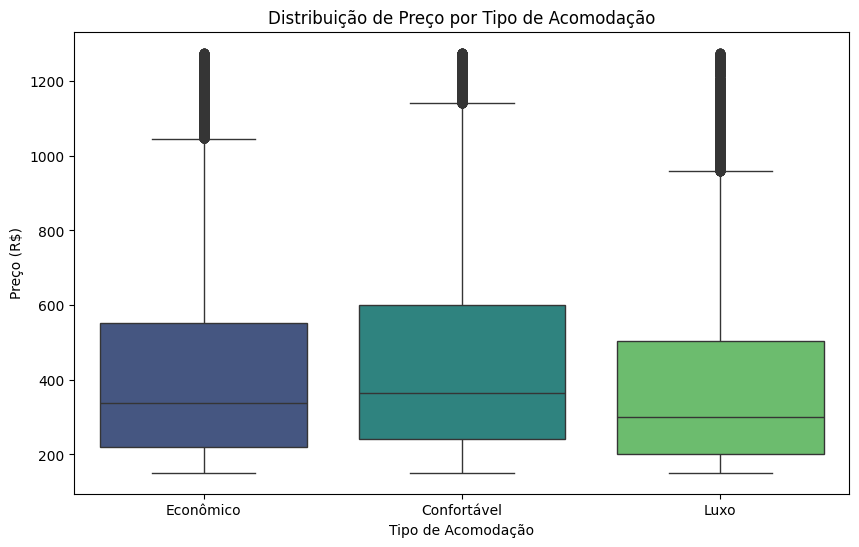

```python
#Comparação de Preços por Tipo de Acomodaçãoabs
plt.figure(figsize=(10, 6))
sns.boxplot(data=df_airbnb, x='tipo_acomodacao', y='price', hue='tipo_acomodacao', palette='viridis')
plt.title("Distribuição de Preço por Tipo de Acomodação")
plt.xlabel("Tipo de Acomodação")
plt.ylabel("Preço (R$)")
plt.show()
```

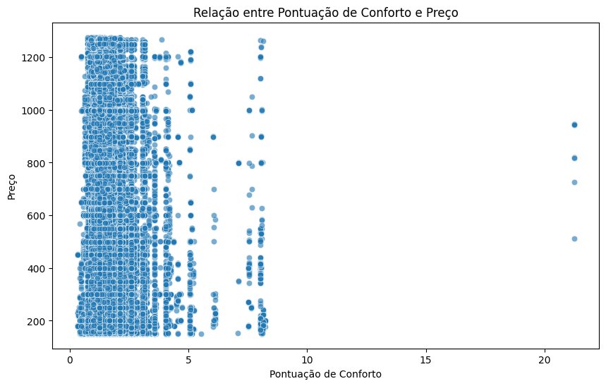

```python
#Relação entre Pontuação de Conforto e Preço
plt.figure(figsize=(10, 6))
sns.scatterplot(data=df_airbnb, x='pontuacao_conforto', y='price', alpha=0.6)
plt.title("Relação entre Pontuação de Conforto e Preço")
plt.xlabel("Pontuação de Conforto")
plt.ylabel("Preço")
plt.show()
```

## Teste de Hipotese:

Para comparar as variaveis a seguir vou utilizar o teste t, abaixo os principais conceitos desta tecnica.

**Principais conceitos do teste t**

- **Hipóteses:** No teste t, normalmente definimos uma **hipótese nula (H₀)**, que sugere que não há diferença entre as médias, e uma **hipótese alternativa (H₁)**, que propõe que há uma diferença.
- **Valor-p (p-value):** Indica a probabilidade de observarmos os dados caso a hipótese nula seja verdadeira. Um valor-p baixo (geralmente menor que 0,05) sugere que rejeitamos a hipótese nula e aceitamos que há uma diferença significativa.
- **Distribuição t:** O teste t baseia-se na distribuição t de Student, que se assemelha à distribuição normal, mas é usada para amostras menores.

### 1. Comparação de Preços entre Tipos de Acomodação

**Propósito:**

- Entender se o tipo de acomodação impacta o preço de maneira significativa.

```python
# Filtrar preços de acomodações Econômicas e Luxo
precos_economico = df_airbnb[df_airbnb['tipo_acomodacao'] == 'Econômico']['price']
precos_luxo = df_airbnb[df_airbnb['tipo_acomodacao'] == 'Confortável']['price']

# Realizar o teste t
t_stat, p_val = ttest_ind(precos_economico, precos_luxo)

print(f"Estatística t: {t_stat}")
print(f"Valor p: {p_val}")

# Interpretação
if p_val < 0.05:
    print("Rejeitamos H0: Há uma diferença significativa no preço entre acomodações Econômico e Confortável.")
else:
    print("Falhamos em rejeitar H0: Não há diferença significativa no preço entre acomodações Econômico e Confortável.")
```

```
Estatística t: -42.05333763738626
Valor p: 0.0
Rejeitamos H0: Há uma diferença significativa no preço entre acomodações Econômico e Confortável.
```

### 2. Impacto de Comodidades Específicas no Preço (Teste T ou ANOVA)

**Propósito:**

- Verificar se há diferença no preço médio entre imóveis com e sem uma comodidade específica, como Wi-Fi ou ar-condicionado.

```python
# Filtrar preços de imóveis com e sem Wi-Fi
precos_com_wifi = df_airbnb[df_airbnb['has_wifi'] == 1]['price']
precos_sem_wifi = df_airbnb[df_airbnb['has_wifi'] == 0]['price']

# Realizar o teste t
t_stat, p_val = ttest_ind(precos_com_wifi, precos_sem_wifi)

print(f"Estatística t: {t_stat}")
print(f"Valor p: {p_val}")

# Interpretação
if p_val < 0.05:
    print("Rejeitamos H0: Há uma diferença significativa no preço entre imóveis com e sem Wi-Fi.")
else:
    print("Falhamos em rejeitar H0: Não há diferença significativa no preço entre imóveis com e sem Wi-Fi.")
```

```
Estatística t: -19.0690841900493
Valor p: 4.822840170672431e-81
Rejeitamos H0: Há uma diferença significativa no preço entre imóveis com e sem Wi-Fi.
```

### 3. Diferença de Preço entre Bairros (ANOVA)

**Objetivo:**

- Determinar se há uma diferença significativa no preço médio entre diferentes bairros.

```python
# Separar os preços por bairro
bairros = df_airbnb['neighbourhood_cleansed'].unique()
precos_por_bairro = [df_airbnb[df_airbnb['neighbourhood_cleansed'] == bairro]['price'] for bairro in bairros]

# Realizar a ANOVA
f_stat, p_val = f_oneway(*precos_por_bairro)

print(f"Estatística F: {f_stat}")
print(f"Valor p: {p_val}")

# Interpretação
if p_val < 0.05:
    print("Rejeitamos H0: Existe uma diferença significativa nos preços médios entre os bairros.")
else:
    print("Falhamos em rejeitar H0: Não há diferença significativa nos preços médios entre os bairros.")
```

```
Estatística F: 181.05699244873253
Valor p: 0.0
Rejeitamos H0: Existe uma diferença significativa nos preços médios entre os bairros.
```

```python
# Preparar os dados
X = df_airbnb['pontuacao_conforto']
y = df_airbnb['price']
X = sm.add_constant(X)  # Adicionar uma constante para o interceptom no caso de variavel dependente (x) conter 0

#Tratar valores infinitos e nulos
X = X.replace([np.inf, -np.inf], np.nan).dropna() #Substituindo valores inf e Nan
y = y[X.index] # mantendo a mesma quantidade de index de X em y

# Ajustar o modelo de regressão linear
modelo = sm.OLS(y, X).fit() #(OLS - Ordinary Least Squares)

# Exibir o resumo do modelo
print(modelo.summary())
```

```
                            OLS Regression Results
==============================================================================
Dep. Variable:                  price   R-squared:                       0.009
Model:                            OLS   Adj. R-squared:                  0.009
Method:                 Least Squares   F-statistic:                     4909.
Date:                Thu, 21 Nov 2024   Prob (F-statistic):               0.00
Time:                        22:06:36   Log-Likelihood:            -3.9899e+06
No. Observations:              565582   AIC:                         7.980e+06
Df Residuals:                  565580   BIC:                         7.980e+06
Df Model:                           1
Covariance Type:            nonrobust
======================================================================================
                         coef    std err          t      P>|t|      [0.025      0.975]
--------------------------------------------------------------------------------------
const                531.2682      1.197    443.697      0.000     528.921     533.615
pontuacao_conforto   -51.9694      0.742    -70.064      0.000     -53.423     -50.516
==============================================================================
Omnibus:                    77877.075   Durbin-Watson:                   1.845
Prob(Omnibus):                  0.000   Jarque-Bera (JB):           114863.538
Skew:                           1.096   Prob(JB):                         0.00
Kurtosis:                       3.263   Cond. No.                         7.04
==============================================================================

Notes:
[1] Standard Errors assume that the covariance matrix of the errors is correctly specified.
```

#### Nota:

- **R-squared e Adjusted R-squared :** valor é 0.9% o que significa que o modelo explica apenas cerca de 0,9% da variabilidade no preço. Com isso a variavel conform tem um impacto muito pequeno na variação dos preços.
- **Adjusted R-squared:** O valor ajustado de R² também é 0.009, confirmando que a adição de pontuacao_conforto ao modelo tem uma contribuição muito limitada para explicar a variabilidade nos preços.
- **Estatística F e Prob (F-statistic):** F-statistic: A estatística F do modelo é 4909, com um valor p de 0.00, indicando que o modelo como um todo é estatisticamente significativo (ou seja, o coeficiente de pontuacao_conforto não é zero).
- **Prob (F-statistic):** Um valor de 0.00 indica que existe uma probabilidade muito baixa de que os coeficientes sejam zero, o que sugere que pontuacao_conforto tem algum efeito no preço, mesmo que pequeno.
- **Coeficientes (coef):** Intercepto (const): O valor do intercepto é 531.2682, o que indica que, na ausência de pontuacao_conforto (quando pontuacao_conforto é zero), o valor médio estimado para o preço é aproximadamente 531.27.as_integer_ratio
- **Coeficiente de pontuacao_conforto:** O valor é -51.9694, indicando que, a cada aumento de uma unidade na pontuacao_conforto, o preço médio dos imóveis diminui aproximadamente em R$ 51,97, mantendo outras variáveis constantes.
  - **Interpretação:** Embora o coeficiente de pontuacao_conforto seja estatisticamente significativo, seu efeito é negativo. Isso pode ser contraintuitivo se esperávamos que maior conforto estivesse associado a preços mais altos. Vendo este comportamento e analises anteriores, entendo que o ideial seria analisar a fundo a potuação de conforto que esta atrelado as comodidades, em algumas analises anteriores foi possivel identificar que alguns imoveis possuem mais de 20 amenidades, por essa e outras analises vejo que a interferencia desta variavel no procesos é significativa, porem não é um fator determinante, com isso nao seguirei com a investigação dos outliers em amenidades.
- **Erro Padrão (std err):** O erro padrão do coeficiente de pontuacao_conforto é 0.742, e o erro padrão do intercepto é 1.197. Valores baixos de erro padrão indicam que a estimativa dos coeficientes é relativamente precisa, mesmo que o impacto da variável seja pequeno.
- **Intervalo de confiança**: O intervalo de confiança de 95% para o coeficiente de pontuacao_conforto é de [-53.423, -50.516]. Como o intervalo não cruza zero, isso confirma que o coeficiente de pontuacao_conforto é estatisticamente significativo, apesar do efeito ser negativo.

#### Resumo da Interpretação

1. A variável pontuacao_conforto tem um impacto estatisticamente significativo, porém pequeno e negativo, no preço.
2. O baixo valor de R² sugere que pontuacao_conforto explica muito pouco da variabilidade no preço, e é provável que outras variáveis sejam mais importantes para prever os preços dos imóveis.
3. A relação negativa entre conforto e preço é interessante e pode indicar alguma característica específica do mercado que merece mais investigação.

## Preparação e modelagem para predição de preços

```python
# Removendo a coluna amenities, pois nela temos uma lista de comodidades que ja destribui em outras colunas em passos anteriores.
df_airbnb = df_airbnb.drop('amenities', axis=1)
```

```python
#Preparação dos dados

# Dividir dados em treino e teste codificar variáveis categóricas em variáveis dummy (One-Hot Encoding)
X = pd.get_dummies(df_airbnb.drop('price', axis=1), drop_first=True)
y = df_airbnb['price']

#Tratar valores infinitos e nulos
X = X.replace([np.inf, -np.inf], np.nan).dropna() #Substituindo valores inf e Nan
y = y[X.index] # mantendo a mesma quantidade de index de X em y


X_train, X_test, y_train, y_test = train_test_split(X, y, test_size=0.2, random_state=42)

# Escalonamento das variáveis (para KNN e Redes Neurais)
scaler = StandardScaler()
X_train_scaled = scaler.fit_transform(X_train)
X_test_scaled = scaler.transform(X_test)
```

#### Implementação dos Modelos e Métricas de Avaliação

```python
# função para calcular as metricas dos models
def avaliar_modelo(y_true, y_pred, nome_modelo):
    mae = mean_absolute_error(y_true, y_pred)
    rmse = np.sqrt(mean_squared_error(y_true, y_pred))
    r2 = r2_score(y_true, y_pred)
    print(f"{nome_modelo} - MAE: {mae:.2f}, RMSE: {rmse:.2f}, R²: {r2:.2f}")
    return mae, rmse, r2
```

#### Regressão Linear Múltipla

```python
#Treinamento do modelo de regressao linear múltipla
modelo_lr = LinearRegression()
modelo_lr.fit(X_train, y_train)
y_pred_lr = modelo_lr.predict(X_test)
avaliar_modelo(y_test, y_pred_lr, "Regressão Linear Múltipla")
```

```
Regressão Linear Múltipla - MAE: 188.42, RMSE: 242.89, R²: 0.25
```

```
(188.41602974331863, 242.89197199529283, 0.25276151939992086)
```

#### Random Forest Regressor

```python
#Treinamento do modelo de Random Forest
modelo_rf = RandomForestRegressor(random_state=42)
modelo_rf.fit(X_train, y_train)
y_pred_rf = modelo_rf.predict(X_test)
avaliar_modelo(y_test, y_pred_rf, "Random Forest Regressor")
```

```
Random Forest Regressor - MAE: 15.32, RMSE: 46.67, R²: 0.97
```

```
(15.320583999004823, 46.67227897494636, 0.9724100494301773)
```

#### Gradient Boosting (XGBoost)

```python
modelo_xgb = XGBRegressor(random_state=42)
modelo_xgb.fit(X_train, y_train)
y_pred_xgb = modelo_xgb.predict(X_test)
avaliar_modelo(y_test, y_pred_xgb, "XGBoost Regressor")
```

```
XGBoost Regressor - MAE: 145.33, RMSE: 194.68, R²: 0.52
```

```
(145.32940819697257, 194.67694866268278, 0.5199770869958068)
```

#### K-Nearest Neighbors (KNN) Regressor

```python
modelo_knn = KNeighborsRegressor(n_neighbors=5)
modelo_knn.fit(X_train_scaled, y_train)
y_pred_knn = modelo_knn.predict(X_test_scaled)
avaliar_modelo(y_test, y_pred_knn, "K-Nearest Neighbors Regressor")
```

```
K-Nearest Neighbors Regressor - MAE: 68.87, RMSE: 129.25, R²: 0.79
```

```
(68.86918066872218, 129.2498184237988, 0.7884111440832353)
```

#### Regressão Lasso

```python
modelo_lasso = Lasso(alpha=0.1)
modelo_lasso.fit(X_train, y_train)
y_pred_lasso = modelo_lasso.predict(X_test)
avaliar_modelo(y_test, y_pred_lasso, "Regressão Lasso")
```

```
Regressão Lasso - MAE: 189.33, RMSE: 243.76, R²: 0.25
```

```
(189.33444181072642, 243.76167450420704, 0.24740079337653587)
```

#### Rede Neural (MLP Regressor)

```python
modelo_mlp = MLPRegressor(hidden_layer_sizes=(50, 50), max_iter=300, solver='sgd', batch_size=64, random_state=42)
modelo_mlp.fit(X_train_scaled, y_train)
y_pred_mlp = modelo_mlp.predict(X_test_scaled)
avaliar_modelo(y_test, y_pred_mlp, "Rede Neural MLP Regressor")
```

```
Rede Neural MLP Regressor - MAE: 227.40, RMSE: 280.99, R²: -0.00
```

```
(227.39833225392817, 280.986064979364, -5.691312809030791e-06)
```

## Comparação dos Modelos

```python
#Criando um novo df com os resultados
resultados = {
    "Modelo": ["Regressão Linear Múltipla", "Random Forest", "XGBoost", "KNN", "Lasso", "MLP Regressor"],
    "MAE": [mean_absolute_error(y_test, y_pred_lr),
            mean_absolute_error(y_test, y_pred_rf),
            mean_absolute_error(y_test, y_pred_xgb),
            mean_absolute_error(y_test, y_pred_knn),
            mean_absolute_error(y_test, y_pred_lasso),
            mean_absolute_error(y_test, y_pred_mlp)],
    "RMSE": [np.sqrt(mean_squared_error(y_test, y_pred_lr)),
             np.sqrt(mean_squared_error(y_test, y_pred_rf)),
             np.sqrt(mean_squared_error(y_test, y_pred_xgb)),
             np.sqrt(mean_squared_error(y_test, y_pred_knn)),
             np.sqrt(mean_squared_error(y_test, y_pred_lasso)),
             np.sqrt(mean_squared_error(y_test, y_pred_mlp))],
    "R²": [r2_score(y_test, y_pred_lr),
           r2_score(y_test, y_pred_rf),
           r2_score(y_test, y_pred_xgb),
           r2_score(y_test, y_pred_knn),
           r2_score(y_test, y_pred_lasso),
           r2_score(y_test, y_pred_mlp)]
}

df_resultados = pd.DataFrame(resultados)
print(df_resultados)
```

```
                      Modelo         MAE        RMSE        R²
0  Regressão Linear Múltipla  188.416030  242.891972  0.252762
1              Random Forest   15.320584   46.672279  0.972410
2                    XGBoost  145.329408  194.676949  0.519977
3                        KNN   68.869181  129.249818  0.788411
4                      Lasso  189.334442  243.761675  0.247401
5              MLP Regressor  227.398332  280.986065 -0.000006
```

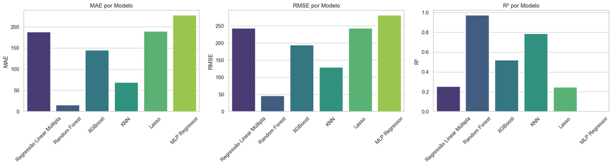

```python
# Configuração do estilo do Seaborn
sns.set(style="whitegrid")

# Plotar gráficos de barras para cada métrica
fig, axes = plt.subplots(1, 3, figsize=(18, 5))

# Gráfico MAE
sns.barplot(data=df_resultados, x="Modelo", y="MAE", hue="Modelo", ax=axes[0], palette="viridis")
axes[0].set_title("MAE por Modelo")
axes[0].set_ylabel("MAE")
axes[0].set_xlabel("")
axes[0].tick_params(axis="x", rotation=45)

# Gráfico RMSE
sns.barplot(data=df_resultados, x="Modelo", y="RMSE", hue="Modelo", ax=axes[1], palette="viridis")
axes[1].set_title("RMSE por Modelo")
axes[1].set_ylabel("RMSE")
axes[1].set_xlabel("")
axes[1].tick_params(axis="x", rotation=45)

# Gráfico R²
sns.barplot(data=df_resultados, x="Modelo", y="R²", hue="Modelo", ax=axes[2], palette="viridis")
axes[2].set_title("R² por Modelo")
axes[2].set_ylabel("R²")
axes[2].set_xlabel("")
axes[2].tick_params(axis="x", rotation=45)

plt.tight_layout()
plt.show()
```

#### Conclusão: Melhor Modelo

**Com base nas métricas:**

O Random Forest é claramente o melhor modelo. Ele tem o menor MAE e RMSE, o que indica que ele comete os menores erros absolutos e quadráticos em relação aos dados reais. Além disso, o R² mais alto mostra que o modelo Random Forest explica quase toda a variabilidade dos preços, no entanto irei aplicar a validação cruzada para identificar como o modelo se comparta em várias divisões do conjunto de dados de treino.

```python
## Validação cruzada para avaliar o modelo Rf que rain, cv=5, scoring='r2')
scores = cross_val_score(modelo_rf, X_train_scaled, y_train, cv=5, scoring='r2')
print(f"Resultados da Validação Cruzada R²: {scores}")
print(f"Média do R²: {np.mean(scores):.3f}")
print(f"Desvio Padrão do R²: {np.std(scores):.3f}")
```

[output not shown]

#### **Objetivo da Validação Cruzada e Conclusão**

O principal objetivo da validação cruzada era verificar a consistência do modelo em várias divisões do conjunto de dados de treino, o que ajuda a identificar se o modelo tem um bom desempenho geral e se é robusto.

```python
#Salvar o modelo RF que melhor performou em todas as analises

# Salvar o modelo Random Forest em um arquivo
joblib.dump(modelo_rf, '../Results/modelo_random_forest.pkl')
```

```
['../Results/modelo_random_forest.pkl']
```